# Ford GoBike System Data Exploration

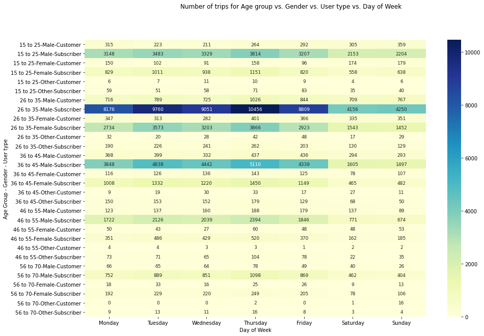

```python
ga = df.groupby(['age_bins', 'member_gender', 'user_type', 'trip_day'])['duration_min'].count().reset_index(name="count")
ga= ga.pivot_table(index=['age_bins', 'member_gender', 'user_type'], columns="trip_day", values='count', aggfunc = np.sum)

f4 = plt.figure(new_figId(), figsize=(15, 10))
f4.suptitle('Number of trips for Age group vs. Gender vs. User type vs. Day of Week')
g = sb.heatmap(ga, fmt='d',  annot=True, cmap='YlGnBu', annot_kws={'size': 9})
g.set(xlabel='Day of Week', ylabel='Age Group - Gender - User type')
g.set_yticklabels(g.get_yticklabels(), rotation = 0, fontsize = 10)
visualize(g)
```

The hight number of trips is taking place on Thursday by Male Subscribers of age between 26 and 35

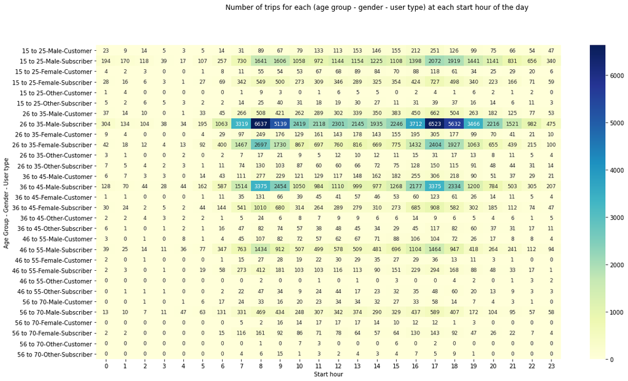

```python
ga = df.groupby(['age_bins', 'member_gender', 'user_type', 'start_hour'])['duration_min'].count().reset_index(name="count")
ga= ga.pivot_table(index=['age_bins', 'member_gender', 'user_type'], columns="start_hour", values='count', aggfunc = np.sum)

f4 = plt.figure(new_figId(), figsize=(18, 10))
f4.suptitle('Number of trips for each (age group - gender - user type) at each start hour of the day')
g = sb.heatmap(ga, fmt='d',  annot=True, cmap='YlGnBu', annot_kws={'size': 9})
g.set(xlabel='Start hour', ylabel='Age Group - Gender - User type')
g.set_yticklabels(g.get_yticklabels(), rotation = 0, fontsize = 10)
visualize(g)
```

The hight number of trips is taking place at 8:00 and 17:00 by Male Subscribers of age between 26 and 35, followed by trips at the same times by Male Subscribers of age between 36 and 45

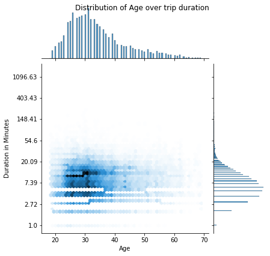

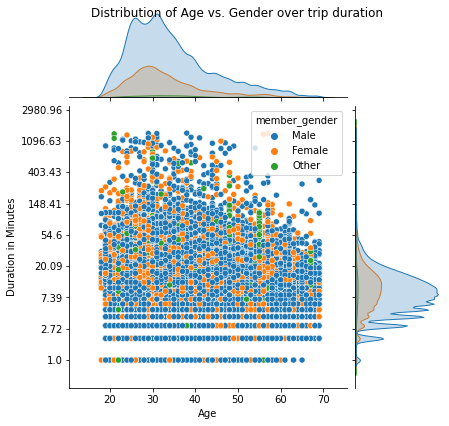

```python
import warnings
warnings.filterwarnings("ignore")

dinsty = sb.jointplot(data=df, x="member_age", y="log_duration_min", kind='hex', height=6, ratio=3, space=0.1);
labels = dinsty.ax_joint.get_yticks();
dinsty.ax_joint.set_yticklabels([round(np.exp(float(i)),2) for i in labels]);
dinsty.ax_joint.set(xlabel='Age', ylabel='Duration in Minutes')
dinsty.fig.suptitle("Distribution of Age over trip duration")

dst_gender = sb.jointplot(data=df, x="member_age", y="log_duration_min", hue='member_gender', height=6, ratio=3, space=0.1);
labels = dst_gender.ax_joint.get_yticks();
dst_gender.ax_joint.set_yticklabels([round(np.exp(float(i)),2) for i in labels]);
dst_gender.ax_joint.set(xlabel='Age', ylabel='Duration in Minutes')
dst_gender.fig.suptitle("Distribution of Age vs. Gender over trip duration")

visualize(dinsty, dst_gender)
```

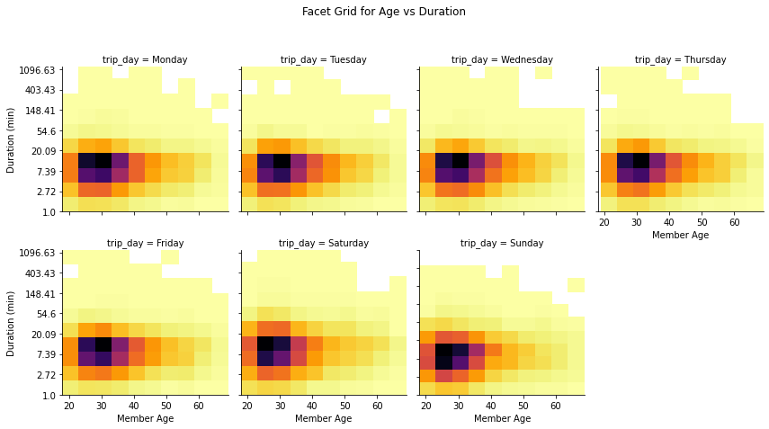

```python
def hist2dgrid(x, y, **kwargs):
    palette = kwargs.pop('color');
    plt.hist2d(x, y, cmap = palette, cmin = 0.5);
    ticks = plt.yticks()[0]
    plt.yticks(ticks, [round(np.exp(i),2) for i in ticks]);

g = sb.FacetGrid(data= df, col = 'trip_day', col_wrap = 4, height = 3)
g.map(hist2dgrid, 'member_age', 'log_duration_min', color = 'inferno_r');
g.fig.suptitle('Facet Grid for Age vs Duration', y=1.1)
g.set_xlabels('Member Age');
g.set_ylabels('Duration (min)');
```

Trip durations in weekends are slightly longer that weekdays

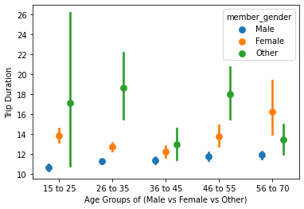

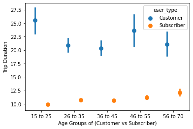

```python
fig = plt.figure(new_figId())
d_g = sb.pointplot(data =df, x = 'age_bins', y = 'duration_min', hue = 'member_gender', linestyles = '', dodge = 0.4)
d_g.set(xlabel='Age Groups of (Male vs Female vs Other)', ylabel='Trip Duration')

fig = plt.figure(new_figId())
d_ut = sb.pointplot(data =df, x = 'age_bins', y = 'duration_min', hue = 'user_type', linestyles = '', dodge = 0.4)
d_ut.set(xlabel='Age Groups of (Customer vs Subscriber)', ylabel='Trip Duration')

visualize( d_g, d_ut)
```

# Multivariate Exploration Summary